# STAT 4620 Project Data Preparation

Luke Dinan

11/22/2021

##### Load Libraries/Data

```r
library(tidyverse)
library(magrittr)
library(glmnet)
load("Ames/ames.Rdata")
```

##### Replace NA Categorical

Training Data: replace categorical NA with more descriptive value

```r
train$Alley <- ifelse(is.na(train$Alley), "None", train$Alley)
train$Fireplace.Qu <- ifelse(is.na(train$Fireplace.Qu), "None", train$Fireplace.Qu)
train$Bsmt.Qual <- ifelse(is.na(train$Bsmt.Qual), "No Basement", train$Bsmt.Qual)
train$Bsmt.Cond <- ifelse(is.na(train$Bsmt.Cond), "No Basement", train$Bsmt.Cond)
train$Bsmt.Exposure <- ifelse(is.na(train$Bsmt.Exposure), "No Basement", train$Bsmt.Exposure)
train$BsmtFin.Type.1 <- ifelse(is.na(train$BsmtFin.Type.1), "No Basement", train$BsmtFin.Type.1)
train$BsmtFin.Type.2 <- ifelse(is.na(train$BsmtFin.Type.2), "No Basement", train$BsmtFin.Type.2)
train$Pool.QC <- ifelse(is.na(train$Pool.QC), "No Pool", train$Pool.QC)
train$Garage.Type <- ifelse(is.na(train$Garage.Type), "No Garage", train$Garage.Type)
train$Garage.Finish <- ifelse(is.na(train$Garage.Finish), "No Garage", train$Garage.Finish)
train$Garage.Qual <- ifelse(is.na(train$Garage.Qual), "No Garage", train$Garage.Qual)
train$Garage.Cond <- ifelse(is.na(train$Garage.Cond), "No Garage", train$Garage.Cond)
train$Fence <- ifelse(is.na(train$Fence), "No Fence", train$Fence)
train$Misc.Feature <- ifelse(is.na(train$Misc.Feature), "None", train$Misc.Feature)
```

Testing Data: replace categorical NA with more descriptive value

```r
test$Alley <- ifelse(is.na(test$Alley), "None", test$Alley)
test$Fireplace.Qu <- ifelse(is.na(test$Fireplace.Qu), "None", test$Fireplace.Qu)
test$Bsmt.Qual <- ifelse(is.na(test$Bsmt.Qual), "No Basement", test$Bsmt.Qual)
test$Bsmt.Cond <- ifelse(is.na(test$Bsmt.Cond), "No Basement", test$Bsmt.Cond)
test$Bsmt.Exposure <- ifelse(is.na(test$Bsmt.Exposure), "No Basement", test$Bsmt.Exposure)
test$BsmtFin.Type.1 <- ifelse(is.na(test$BsmtFin.Type.1), "No Basement", test$BsmtFin.Type.1)
test$BsmtFin.Type.2 <- ifelse(is.na(test$BsmtFin.Type.2), "No Basement", test$BsmtFin.Type.2)
test$Pool.QC <- ifelse(is.na(test$Pool.QC), "No Pool", test$Pool.QC)
test$Garage.Type <- ifelse(is.na(test$Garage.Type), "No Garage", test$Garage.Type)
test$Garage.Finish <- ifelse(is.na(test$Garage.Finish), "No Garage", test$Garage.Finish)
test$Garage.Qual <- ifelse(is.na(test$Garage.Qual), "No Garage", test$Garage.Qual)
test$Garage.Cond <- ifelse(is.na(test$Garage.Cond), "No Garage", test$Garage.Cond)
test$Fence <- ifelse(is.na(test$Fence), "No Fence", test$Fence)
test$Misc.Feature <- ifelse(is.na(test$Misc.Feature), "None", test$Misc.Feature)
```

##### Impute Continuous Nulls

Training Data: impute missing values with the median

```r
train$Lot.Frontage[is.na(train$Lot.Frontage)]<-median(train$Lot.Frontage,na.rm=TRUE)
train$Garage.Yr.Blt[is.na(train$Garage.Yr.Blt)]<-median(train$Garage.Yr.Blt,na.rm=TRUE)
train$Mas.Vnr.Area[is.na(train$Mas.Vnr.Area)]<-median(train$Mas.Vnr.Area,na.rm=TRUE)
train$Bsmt.Full.Bath[is.na(train$Bsmt.Full.Bath)]<-median(train$Bsmt.Full.Bath,na.rm=TRUE)
train$Bsmt.Half.Bath[is.na(train$Bsmt.Half.Bath)]<-median(train$Bsmt.Half.Bath,na.rm=TRUE)
train$BsmtFin.SF.1[is.na(train$BsmtFin.SF.1)]<-median(train$BsmtFin.SF.1,na.rm=TRUE)
train$BsmtFin.SF.2[is.na(train$BsmtFin.SF.2)]<-median(train$BsmtFin.SF.2,na.rm=TRUE)
train$Bsmt.Unf.SF[is.na(train$Bsmt.Unf.SF)]<-median(train$Bsmt.Unf.SF,na.rm=TRUE)
train$Total.Bsmt.SF[is.na(train$Total.Bsmt.SF)]<-median(train$Total.Bsmt.SF,na.rm=TRUE)
train$Garage.Cars[is.na(train$Garage.Cars)]<-median(train$Garage.Cars,na.rm=TRUE)
train$Garage.Area[is.na(train$Garage.Area)]<-median(train$Garage.Area,na.rm=TRUE)
```

Test Data: impute missing values with the median

```r
test$Lot.Frontage[is.na(test$Lot.Frontage)]<-median(test$Lot.Frontage,na.rm=TRUE)
test$Garage.Yr.Blt[is.na(test$Garage.Yr.Blt)]<-median(test$Garage.Yr.Blt,na.rm=TRUE)
test$Mas.Vnr.Area[is.na(test$Mas.Vnr.Area)]<-median(test$Mas.Vnr.Area,na.rm=TRUE)
test$Bsmt.Full.Bath[is.na(test$Bsmt.Full.Bath)]<-median(test$Bsmt.Full.Bath,na.rm=TRUE)
test$Bsmt.Half.Bath[is.na(test$Bsmt.Half.Bath)]<-median(test$Bsmt.Half.Bath,na.rm=TRUE)
test$BsmtFin.SF.1[is.na(test$BsmtFin.SF.1)]<-median(test$BsmtFin.SF.1,na.rm=TRUE)
test$BsmtFin.SF.2[is.na(test$BsmtFin.SF.2)]<-median(test$BsmtFin.SF.2,na.rm=TRUE)
test$Bsmt.Unf.SF[is.na(test$Bsmt.Unf.SF)]<-median(test$Bsmt.Unf.SF,na.rm=TRUE)
test$Total.Bsmt.SF[is.na(test$Total.Bsmt.SF)]<-median(test$Total.Bsmt.SF,na.rm=TRUE)
test$Garage.Cars[is.na(test$Garage.Cars)]<-median(test$Garage.Cars,na.rm=TRUE)
test$Garage.Area[is.na(test$Garage.Area)]<-median(test$Garage.Area,na.rm=TRUE)
```

No null values for train or test set

```r
sapply(train, function(y) sum(length(which(is.na(y)))))
```

```
##           Order             PID     MS.SubClass       MS.Zoning    Lot.Frontage
##               0               0               0               0               0
##        Lot.Area          Street           Alley       Lot.Shape    Land.Contour
##               0               0               0               0               0
##       Utilities      Lot.Config      Land.Slope    Neighborhood     Condition.1
##               0               0               0               0               0
##     Condition.2       Bldg.Type     House.Style    Overall.Qual    Overall.Cond
##               0               0               0               0               0
##      Year.Built  Year.Remod.Add      Roof.Style       Roof.Matl    Exterior.1st
##               0               0               0               0               0
##    Exterior.2nd    Mas.Vnr.Type    Mas.Vnr.Area      Exter.Qual      Exter.Cond
##               0               0               0               0               0
##      Foundation       Bsmt.Qual       Bsmt.Cond   Bsmt.Exposure  BsmtFin.Type.1
##               0               0               0               0               0
##    BsmtFin.SF.1  BsmtFin.Type.2    BsmtFin.SF.2     Bsmt.Unf.SF   Total.Bsmt.SF
##               0               0               0               0               0
##         Heating      Heating.QC     Central.Air      Electrical     X1st.Flr.SF
##               0               0               0               0               0
##     X2nd.Flr.SF Low.Qual.Fin.SF     Gr.Liv.Area  Bsmt.Full.Bath  Bsmt.Half.Bath
##               0               0               0               0               0
##       Full.Bath       Half.Bath   Bedroom.AbvGr   Kitchen.AbvGr    Kitchen.Qual
##               0               0               0               0               0
##   TotRms.AbvGrd      Functional      Fireplaces    Fireplace.Qu     Garage.Type
##               0               0               0               0               0
##   Garage.Yr.Blt   Garage.Finish     Garage.Cars     Garage.Area     Garage.Qual
##               0               0               0               0               0
##     Garage.Cond     Paved.Drive    Wood.Deck.SF   Open.Porch.SF  Enclosed.Porch
##               0               0               0               0               0
##     X3Ssn.Porch    Screen.Porch       Pool.Area         Pool.QC           Fence
##               0               0               0               0               0
##    Misc.Feature        Misc.Val         Mo.Sold         Yr.Sold       Sale.Type
##               0               0               0               0               0
##  Sale.Condition       SalePrice
##               0               0
```

```r
sapply(test, function(y) sum(length(which(is.na(y)))))
```

```
##           Order             PID     MS.SubClass       MS.Zoning    Lot.Frontage
##               0               0               0               0               0
##        Lot.Area          Street           Alley       Lot.Shape    Land.Contour
##               0               0               0               0               0
##       Utilities      Lot.Config      Land.Slope    Neighborhood     Condition.1
##               0               0               0               0               0
##     Condition.2       Bldg.Type     House.Style    Overall.Qual    Overall.Cond
##               0               0               0               0               0
##      Year.Built  Year.Remod.Add      Roof.Style       Roof.Matl    Exterior.1st
##               0               0               0               0               0
##    Exterior.2nd    Mas.Vnr.Type    Mas.Vnr.Area      Exter.Qual      Exter.Cond
##               0               0               0               0               0
##      Foundation       Bsmt.Qual       Bsmt.Cond   Bsmt.Exposure  BsmtFin.Type.1
##               0               0               0               0               0
##    BsmtFin.SF.1  BsmtFin.Type.2    BsmtFin.SF.2     Bsmt.Unf.SF   Total.Bsmt.SF
##               0               0               0               0               0
##         Heating      Heating.QC     Central.Air      Electrical     X1st.Flr.SF
##               0               0               0               0               0
##     X2nd.Flr.SF Low.Qual.Fin.SF     Gr.Liv.Area  Bsmt.Full.Bath  Bsmt.Half.Bath
##               0               0               0               0               0
##       Full.Bath       Half.Bath   Bedroom.AbvGr   Kitchen.AbvGr    Kitchen.Qual
##               0               0               0               0               0
##   TotRms.AbvGrd      Functional      Fireplaces    Fireplace.Qu     Garage.Type
##               0               0               0               0               0
##   Garage.Yr.Blt   Garage.Finish     Garage.Cars     Garage.Area     Garage.Qual
##               0               0               0               0               0
##     Garage.Cond     Paved.Drive    Wood.Deck.SF   Open.Porch.SF  Enclosed.Porch
##               0               0               0               0               0
##     X3Ssn.Porch    Screen.Porch       Pool.Area         Pool.QC           Fence
##               0               0               0               0               0
##    Misc.Feature        Misc.Val         Mo.Sold         Yr.Sold       Sale.Type
##               0               0               0               0               0
##  Sale.Condition       SalePrice
##               0               0
```

##### MS Subclass

Change type of MS Subclass to Factor

```r
train$MS.SubClass <- as.factor(train$MS.SubClass)
test$MS.SubClass <- as.factor(test$MS.SubClass)
```

```r
table(train$MS.Zoning)
```

```
##
## A (agr) C (all)      FV I (all)      RH      RL      RM
##       2      19     104       2      21    1836     360
```

##### MS Zoning

```r
train$MS.Zoning <- ifelse(train$MS.Zoning %in% c("A (agr)", "C (all)", "I (all)", "RH", "RM"), "other", train$MS.Zoning)
test$MS.Zoning <- ifelse(test$MS.Zoning %in% c("A (agr)", "C (all)", "I (all)", "RH", "RM"), "other", test$MS.Zoning)
```

```r
table(train$MS.Zoning)
```

```
##
##    FV other    RL
##   104   404  1836
```

##### Alley

Dummy Variable for has.alley: seems unlikely type of alley matters, so drop original alley column

```r
train$Has.Alley <- as.factor(ifelse(train$Alley == "None", 0, 1))
test$Has.Alley <- as.factor(ifelse(test$Alley == "None", 0, 1))
train <- select(train, -Alley)
test <- select(test, -Alley)
```

```r
table(train$has.alley)
```

```
## < table of extent 0 >
```

##### Lot.Shape

Lot Shape is ordinal, so we want to have values that are numeric to represent the ordering.

```r
train$Lot.Shape <- case_when(train$Lot.Shape == "Reg" ~ 0,
                             train$Lot.Shape == "IR1" ~ 1,
                             train$Lot.Shape == "IR2" ~ 2,
                             train$Lot.Shape == "IR3" ~ 3)
test$Lot.Shape <- case_when(test$Lot.Shape == "Reg" ~ 0,
                             test$Lot.Shape == "IR1" ~ 1,
                             test$Lot.Shape == "IR2" ~ 2,
                             test$Lot.Shape == "IR3" ~ 3)
```

#### Lot Config

```r
table(train$Lot.Config)
```

```
##
##  Corner CulDSac     FR2     FR3  Inside
##     416     144      59      11    1714
```

Dummy for Inside lot or not, as that is the most frequent value.

```r
train$Lot.Config <- ifelse(train$Lot.Config == "Inside", "Inside", "other")
test$Lot.Config <- ifelse(test$Lot.Config == "Inside", "Inside", "other")
```

```r
table(train$Lot.Config)
```

```
##
## Inside  other
##   1714    630
```

##### Land Slope

Again, Land Slope in ordinal, so encode appropriately.

```r
table(train$Land.Slope)
```

```
##
##  Gtl  Mod  Sev
## 2229  102   13
```

```r
train$Land.Slope <- case_when(train$Land.Slope == "Gtl" ~ 0,
                              train$Land.Slope == "Mod" ~ 1,
                              train$Land.Slope == "Sev" ~ 2)
test$Land.Slope <- case_when(test$Land.Slope == "Gtl" ~ 0,
                              test$Land.Slope == "Mod" ~ 1,
                              test$Land.Slope == "Sev" ~ 2)
```

##### Condition.1

Condition 1 has mostly normal values, so include a dummy for normal or not.

```r
table(train$Condition.1)
```

```
##
## Artery  Feedr   Norm   PosA   PosN   RRAe   RRAn   RRNe   RRNn
##     75    135   2014     15     31     22     39      6      7
```

```r
train$Condition.1 <- ifelse(train$Condition.1 == "Norm", "norm", "other")
test$Condition.1 <- ifelse(test$Condition.1 == "Norm", "norm", "other")
```

```r
table(train$Condition.1)
```

```
##
##  norm other
##  2014   330
```

##### Condition.2

Condition 2 has almost all normal values, so it will include only a dummy variable for normal or not.

```r
table(train$Condition.2)
```

```
##
## Artery  Feedr   Norm   PosA   PosN   RRAe   RRAn   RRNn
##      3     12   2320      3      2      1      1      2
```

```r
train$Condition.2 <- as.factor(ifelse(train$Condition.2 == "Norm", "norm", "other"))
test$Condition.2 <- as.factor(ifelse(test$Condition.2 == "Norm", "norm", "other"))
```

```r
table(train$Condition.2)
```

```
##
##  norm other
##  2320    24
```

##### Roof Style

Only Gable and Hip have significant numbers, so we can include an “other” category for the rest.

```r
train$Roof.Style <- ifelse(train$Roof.Style %in% c("Flat", "Gambrel", "Mansard", "Shed"), "other", train$Roof.Style)
test$Roof.Style <- ifelse(test$Roof.Style %in% c("Flat", "Gambrel", "Mansard", "Shed"), "other", train$Roof.Style)
```

```r
table(train$Roof.Style)
```

```
##
## Gable   Hip other
##  1864   439    41
```

###### Roof Matl

```r
table(train$Roof.Matl)
```

```
##
## ClyTile CompShg Membran    Roll Tar&Grv WdShake WdShngl
##       1    2313       1       1      18       6       4
```

Include dummy variable for CompShg, as it is the only significant quantity

```r
train$Roof.Matl <- ifelse(train$Roof.Matl == "CompShg", "CompShg", "other")
test$Roof.Matl <- ifelse(test$Roof.Matl == "CompShg", "CompShg", "other")
```

```r
table(train$Roof.Matl)
```

```
##
## CompShg   other
##    2313      31
```

##### Exterior 1

```r
table(train$Exterior.1st)
```

```
##
## AsbShng AsphShn BrkComm BrkFace  CBlock CemntBd HdBoard ImStucc MetalSd Plywood
##      36       1       5      68       2     105     371       1     354     174
## PreCast   Stone  Stucco VinylSd Wd Sdng WdShing
##       1       1      32     810     336      47
```

```r
train$Exterior.1st <- ifelse(train$Exterior.1st %in% c("VinylSd", "HdBoard", "Plywood"), train$Exterior.1st, "other")
test$Exterior.1st <- ifelse(test$Exterior.1st %in% c("VinylSd", "HdBoard", "Plywood"), test$Exterior.1st, "other")
```

```r
table(train$Exterior.1st)
```

```
##
## HdBoard   other Plywood VinylSd
##     371     989     174     810
```

##### Exterior 2

Similar to exterior 1, but CmentBd, HdBoard, MetalSd, Plywood, VinylSd, and Wd Sdng are high in frequency.

```r
table(train$Exterior.2nd)
```

```
##
## AsbShng AsphShn Brk Cmn BrkFace  CBlock CmentBd HdBoard ImStucc MetalSd   Other
##      30       3      18      38       2     105     343      12     351       1
## Plywood PreCast   Stone  Stucco VinylSd Wd Sdng Wd Shng
##     217       1       5      36     801     311      70
```

```r
train$Exterior.2nd <- ifelse(train$Exterior.2nd %in% c("CmentBd", "HdBoard", "MetalSd", "Plywood", "VinylSd", "Wd Sdng"), train$Exterior.2nd, "other")
test$Exterior.2nd <- ifelse(test$Exterior.2nd %in% c("CmentBd", "HdBoard", "MetalSd", "Plywood", "VinylSd", "Wd Sdng"), test$Exterior.2nd, "other")
```

```r
table(train$Exterior.2nd)
```

```
##
## CmentBd HdBoard MetalSd   other Plywood VinylSd Wd Sdng
##     105     343     351     216     217     801     311
```

##### Masonry Vnr Type

```r
table(train$Mas.Vnr.Type)
```

```
##
##          BrkCmn BrkFace    None   Stone
##      19      21     689    1406     209
```

```r
train$Mas.Vnr.Type <- ifelse(train$Mas.Vnr.Type %in% c("BrkFace", "None"), train$Mas.Vnr.Type, "other")
test$Mas.Vnr.Type <- ifelse(test$Mas.Vnr.Type %in% c("BrkFace", "None"), test$Mas.Vnr.Type, "other")
```

```r
table(train$Mas.Vnr.Type)
```

```
##
## BrkFace    None   other
##     689    1406     249
```

##### Exter Qual

```r
table(train$Exter.Qual)
```

```
##
##   Ex   Fa   Gd   TA
##   79   28  783 1454
```

Again, ordinal, so encode appropriately.

```r
train$Exter.Qual <- case_when(train$Exter.Qual == "Ex" ~ 4,
                              train$Exter.Qual == "Gd" ~ 3,
                              train$Exter.Qual == "TA" ~ 2,
                              train$Exter.Qual == "Fa" ~ 1,
                              train$Exter.Qual == "Po" ~ 0)
test$Exter.Qual <- case_when(test$Exter.Qual == "Ex" ~ 4,
                              test$Exter.Qual == "Gd" ~ 3,
                              test$Exter.Qual == "TA" ~ 2,
                              test$Exter.Qual == "Fa" ~ 1,
                              test$Exter.Qual == "Po" ~ 0)
```

```r
table(train$Exter.Qual)
```

```
##
##    1    2    3    4
##   28 1454  783   79
```

##### Foundation

Slab, Stone, and Wood are infrequent, so replace those with other.

```r
table(train$Foundation)
```

```
##
## BrkTil CBlock  PConc   Slab  Stone   Wood
##    252    999   1037     42     10      4
```

```r
train$Foundation <- ifelse(train$Foundation %in% c("BrkTil", "CBlock", "PConc"), train$Foundation, "other")
test$Foundation <- ifelse(test$Foundation %in% c("BrkTil", "CBlock", "PConc"), test$Foundation, "other")
```

```r
table(train$Foundation)
```

```
##
## BrkTil CBlock  other  PConc
##    252    999     56   1037
```

##### Create Dummy Variable for whether house has a basement

```r
train$Has.Basement <- ifelse(train$Bsmt.Qual == "No Basement", 0, 1)
test$Has.Basement <- ifelse(test$Bsmt.Qual == "No Basement", 0, 1)
```

##### Bsmt Qual

```r
train$Bsmt.Qual <- ifelse(train$Bsmt.Qual == "", "No Basement", train$Bsmt.Qual)
test$Bsmt.Qual <- ifelse(test$Bsmt.Qual == "", "No Basement", test$Bsmt.Qual)
table(train$Bsmt.Qual)
```

```
##
##          Ex          Fa          Gd No Basement          Po          TA
##         201          69         982          65           2        1025
```

Again, Ordinal. This time, not having a basement is zero, as that seems to make sense in the heirarchy.

```r
train$Bsmt.Qual <- case_when(train$Bsmt.Qual == "Ex" ~ 5,
                             train$Bsmt.Qual == "Gd" ~ 4,
                             train$Bsmt.Qual == "TA" ~ 3,
                             train$Bsmt.Qual == "Fa" ~ 2,
                             train$Bsmt.Qual == "Po" ~ 1,
                             train$Bsmt.Qual == "No Basement" ~ 0)
test$Bsmt.Qual <- case_when(test$Bsmt.Qual == "Ex" ~ 5,
                             test$Bsmt.Qual == "Gd" ~ 4,
                             test$Bsmt.Qual == "TA" ~ 3,
                             test$Bsmt.Qual == "Fa" ~ 2,
                             test$Bsmt.Qual == "Po" ~ 1,
                             test$Bsmt.Qual == "No Basement" ~ 0)
```

```r
table(train$Bsmt.Qual)
```

```
##
##    0    1    2    3    4    5
##   65    2   69 1025  982  201
```

##### Bsmt Cond

Again, ordinal, and represent no basement as zero.

```r
train$Bsmt.Cond <- ifelse(train$Bsmt.Cond == "", "No Basement", train$Bsmt.Cond)
test$Bsmt.Cond <- ifelse(test$Bsmt.Cond == "", "No Basement", test$Bsmt.Cond)
table(train$Bsmt.Cond)
```

```
##
##          Ex          Fa          Gd No Basement          Po          TA
##           2          84         108          65           4        2081
```

```r
train$Bsmt.Cond <- case_when(train$Bsmt.Cond == "Ex" ~ 5,
                             train$Bsmt.Cond == "Gd" ~ 4,
                             train$Bsmt.Cond == "TA" ~ 3,
                             train$Bsmt.Cond == "Fa" ~ 2,
                             train$Bsmt.Cond == "Po" ~ 1,
                             train$Bsmt.Cond == "No Basement" ~ 0)
test$Bsmt.Cond <- case_when(test$Bsmt.Cond == "Ex" ~ 5,
                             test$Bsmt.Cond == "Gd" ~ 4,
                             test$Bsmt.Cond == "TA" ~ 3,
                             test$Bsmt.Cond == "Fa" ~ 2,
                             test$Bsmt.Cond == "Po" ~ 1,
                             test$Bsmt.Cond == "No Basement" ~ 0)
```

```r
table(train$Bsmt.Cond)
```

```
##
##    0    1    2    3    4    5
##   65    4   84 2081  108    2
```

##### Bsmt Exposure

Again, ordinal with No Basement as 0.

```r
train$Bsmt.Exposure <- ifelse(train$Bsmt.Exposure == "", "No Basement", train$Bsmt.Exposure)
test$Bsmt.Exposure <- ifelse(test$Bsmt.Exposure == "", "No Basement", test$Bsmt.Exposure)
table(train$Bsmt.Exposure)
```

```
##
##          Av          Gd          Mn          No No Basement
##         335         230         186        1526          67
```

```r
train$Bsmt.Exposure <- case_when(train$Bsmt.Exposure == "Gd" ~ 4,
                                 train$Bsmt.Exposure == "Av" ~ 3,
                                 train$Bsmt.Exposure == "Mn" ~ 2,
                                 train$Bsmt.Exposure == "No" ~ 1,
                                 train$Bsmt.Exposure == "No Basement" ~ 0)
test$Bsmt.Exposure <- case_when(test$Bsmt.Exposure == "Gd" ~ 4,
                                 test$Bsmt.Exposure == "Av" ~ 3,
                                 test$Bsmt.Exposure == "Mn" ~ 2,
                                 test$Bsmt.Exposure == "No" ~ 1,
                                 test$Bsmt.Exposure == "No Basement" ~ 0)
```

```r
table(train$Bsmt.Exposure)
```

```
##
##    0    1    2    3    4
##   67 1526  186  335  230
```

##### BsmtFin Type 2

```r
table(train$BsmtFin.Type.2)
```

```
##
##                     ALQ         BLQ         GLQ         LwQ No Basement
##           1          45          55          26          68          64
##         Rec         Unf
##          88        1997
```

```r
train$BsmtFin.Type.2 <- ifelse(train$BsmtFin.Type.2 == "Unf", "Unf", "other")
test$BsmtFin.Type.2 <- ifelse(test$BsmtFin.Type.2 == "Unf", "Unf", "other")
```

```r
table(train$BsmtFin.Type.2)
```

```
##
## other   Unf
##   347  1997
```

##### Heating

Dummy variable for GasA

```r
table(train$Heating)
```

```
##
## Floor  GasA  GasW  Grav  OthW  Wall
##     1  2306    20     9     2     6
```

```r
train$Heating <- ifelse(train$Heating == "GasA", "GasA", "other")
test$Heating <- ifelse(test$Heating == "GasA", "GasA", "other")
```

```r
table(train$Heating)
```

```
##
##  GasA other
##  2306    38
```

##### Heating QC

Ordinal, so encode appropriately.

```r
table(train$Heating.QC)
```

```
##
##   Ex   Fa   Gd   Po   TA
## 1182   77  395    3  687
```

```r
train$Heating.QC <- case_when(train$Heating.QC == "Ex" ~ 4,
                              train$Heating.QC == "Gd" ~ 3,
                              train$Heating.QC == "TA" ~ 2,
                              train$Heating.QC == "Fa" ~ 1,
                              train$Heating.QC == "Po" ~ 0)
test$Heating.QC <- case_when(test$Heating.QC == "Ex" ~ 4,
                              test$Heating.QC == "Gd" ~ 3,
                              test$Heating.QC == "TA" ~ 2,
                              test$Heating.QC == "Fa" ~ 1,
                              test$Heating.QC == "Po" ~ 0)
```

```r
table(train$Heating.QC)
```

```
##
##    0    1    2    3    4
##    3   77  687  395 1182
```

##### Electrical

Only include Sbrkr or other.

```r
table(train$Electrical)
```

```
##
##       FuseA FuseF FuseP SBrkr
##     1   155    40     7  2141
```

```r
train$Electrical <- ifelse(train$Electrical == "SBrkr", "SBrkr", "other")
test$Electrical <- ifelse(test$Electrical == "SBrkr", "SBrkr", "other")
```

```r
table(train$Electrical)
```

```
##
## other SBrkr
##   203  2141
```

```r
train$Kitchen.Qual <- case_when(train$Kitchen.Qual == "Ex" ~ 4,
                                train$Kitchen.Qual == "Gd" ~ 3,
                                train$Kitchen.Qual == "TA" ~ 2,
                                train$Kitchen.Qual == "Fa" ~ 1,
                                train$Kitchen.Qual == "Po" ~ 0)
test$Kitchen.Qual <- case_when(test$Kitchen.Qual == "Ex" ~ 4,
                                test$Kitchen.Qual == "Gd" ~ 3,
                                test$Kitchen.Qual == "TA" ~ 2,
                                test$Kitchen.Qual == "Fa" ~ 1,
                                test$Kitchen.Qual == "Po" ~ 0)
```

```r
table(train$Kitchen.Qual)
```

```
##
##    0    1    2    3    4
##    1   56 1212  920  155
```

##### Functional

Dummy variable for functionality less than typical

```r
table(train$Functional)
```

```
##
## Maj1 Maj2 Min1 Min2  Mod  Sal  Sev  Typ
##   18    6   52   60   27    2    1 2178
```

```r
train$Functional <- ifelse(train$Functional == "Typ", "Typ", "BelowTyp")
test$Functional <- ifelse(test$Functional == "Typ", "Typ", "BelowTyp")
```

```r
table(train$Functional)
```

```
##
## BelowTyp      Typ
##      166     2178
```

```r
train$Has.Fireplace <- ifelse(train$Fireplace.Qu == "None", 1, 0)
test$Has.Fireplace <- ifelse(test$Fireplace.Qu == "None", 1, 0)
```

##### Fireplace Qu

```r
train$Fireplace.Qu <- case_when(train$Fireplace.Qu == "Ex" ~ 5,
                                train$Fireplace.Qu == "Gd" ~ 4,
                                train$Fireplace.Qu == "TA" ~ 3,
                                train$Fireplace.Qu == "Fa" ~ 2,
                                train$Fireplace.Qu == "Po" ~ 1,
                                train$Fireplace.Qu == "None" ~ 0)
test$Fireplace.Qu <- case_when(test$Fireplace.Qu == "Ex" ~ 5,
                                test$Fireplace.Qu == "Gd" ~ 4,
                                test$Fireplace.Qu == "TA" ~ 3,
                                test$Fireplace.Qu == "Fa" ~ 2,
                                test$Fireplace.Qu == "Po" ~ 1,
                                test$Fireplace.Qu == "None" ~ 0)
```

```r
table(train$Fireplace.Qu)
```

```
##
##    0    1    2    3    4    5
## 1155   38   54  486  577   34
```

```r
train$Has.Garage <- ifelse(train$Garage.Type == "No Garage", 1, 0)
test$Has.Garage <- ifelse(test$Garage.Type == "No Garage", 1, 0)
```

##### Garage Finish

Ordinal, so encode accordingly.

```r
train$Garage.Finish <- ifelse(train$Garage.Finish == "", "No Garage", train$Garage.Finish)
test$Garage.Finish <- ifelse(test$Garage.Finish == "", "No Garage", test$Garage.Finish)
table(train$Garage.Finish)
```

```
##
##       Fin No Garage       RFn       Unf
##       571       127       650       996
```

```r
train$Garage.Finish <- case_when(train$Garage.Finish == "Fin" ~ 3,
                                 train$Garage.Finish == "RFn" ~ 2,
                                 train$Garage.Finish == "Unf" ~ 1,
                                 train$Garage.Finish == "No Garage" ~ 0)
test$Garage.Finish <- case_when(test$Garage.Finish == "Fin" ~ 3,
                                 test$Garage.Finish == "RFn" ~ 2,
                                 test$Garage.Finish == "Unf" ~ 1,
                                 test$Garage.Finish == "No Garage" ~ 0)
```

```r
table(train$Garage.Finish)
```

```
##
##   0   1   2   3
## 127 996 650 571
```

##### Garage Quality

```r
train$Garage.Qual <- ifelse(train$Garage.Qual == "", "No Garage", train$Garage.Qual)
test$Garage.Qual <- ifelse(test$Garage.Qual == "", "No Garage", test$Garage.Qual)
table(train$Garage.Qual)
```

```
##
##        Ex        Fa        Gd No Garage        Po        TA
##         2       101        17       127         4      2093
```

```r
train$Garage.Qual <- case_when(train$Garage.Qual == "Ex" ~ 5,
                               train$Garage.Qual == "Gd" ~ 4,
                               train$Garage.Qual == "TA" ~ 3,
                               train$Garage.Qual == "Fa" ~ 2,
                               train$Garage.Qual == "Po" ~ 1,
                               train$Garage.Qual == "No Garage" ~ 0)
test$Garage.Qual <- case_when(test$Garage.Qual == "Ex" ~ 5,
                               test$Garage.Qual == "Gd" ~ 4,
                               test$Garage.Qual == "TA" ~ 3,
                               test$Garage.Qual == "Fa" ~ 2,
                               test$Garage.Qual == "Po" ~ 1,
                               test$Garage.Qual == "No Garage" ~ 0)
```

```r
table(train$Garage.Qual)
```

```
##
##    0    1    2    3    4    5
##  127    4  101 2093   17    2
```

#### Paved Drive

There are not many unpaved, so only include a dummy for paved or unpaved.

```r
table(train$Paved.Drive)
```

```
##
##    N    P    Y
##  179   49 2116
```

```r
train$Paved.Drive <- ifelse(train$Paved.Drive == "Y", "Paved", "Unpaved")
test$Paved.Drive <- ifelse(test$Paved.Drive == "Y", "Paved", "Unpaved")
```

```r
table(train$Paved.Drive)
```

```
##
##   Paved Unpaved
##    2116     228
```

##### Pool Area and Quality don’t appear relevant because most don’t have a pool; create a dummy for having a pool instead

```r
train$Has.Pool <- ifelse(train$Pool.QC == "No Pool", 0, 1)
test$Has.Pool <- ifelse(test$Pool.QC == "No Pool", 0, 1)
```

Drop columns:

```r
train <- select(train, -Pool.QC, -Pool.Area)
test <- select(test, -Pool.QC, -Pool.Area)
```

##### Fence

Ordinal, so encode appropriately with no fence as 0.

```r
table(train$Fence)
```

```
##
##    GdPrv     GdWo    MnPrv     MnWw No Fence
##       91       87      269       11     1886
```

```r
train$Fence <- case_when(train$Fence == "GdPrv" ~ 4,
                         train$Fence == "MnPrv" ~ 3,
                         train$Fence == "GdWo" ~ 2,
                         train$Fence == "MnWw" ~ 1,
                         train$Fence == "No Fence" ~ 0)
test$Fence <- case_when(test$Fence == "GdPrv" ~ 4,
                         test$Fence == "MnPrv" ~ 3,
                         test$Fence == "GdWo" ~ 2,
                         test$Fence == "MnWw" ~ 1,
                         test$Fence == "No Fence" ~ 0)
```

```r
table(train$Fence)
```

```
##
##    0    1    2    3    4
## 1886   11   87  269   91
```

##### Misc Feature

Create dummy for having a miscellaneous feature

```r
table(train$Misc.Feature)
```

```
##
## Gar2 None Othr Shed
##    4 2264    3   73
```

```r
train$Misc.Feature <- ifelse(train$Misc.Feature == "None", 0, 1)
test$Misc.Feature <- ifelse(test$Misc.Feature == "None", 0, 1)
```

```r
table(train$Misc.Feature)
```

```
##
##    0    1
## 2264   80
```

##### Sale Type

Eliminate sparse categories, those other than New and Wd

```r
table(train$Sale.Type)
```

```
##
##   COD   Con ConLD ConLI ConLw   CWD   New   Oth   VWD   WD
##    69     5    20     7     6    10   193     6     1  2027
```

```r
train$Sale.Type <- ifelse(train$Sale.Type %in% c("New", "WD "), train$Sale.Type, "other")
test$Sale.Type <- ifelse(test$Sale.Type %in% c("New", "WD "), test$Sale.Type, "other")
```

```r
table(train$Sale.Type)
```

```
##
##   New other   WD
##   193   124  2027
```

##### Filter > 4000 sq. ft. observations

```r
train <- train[train$Gr.Liv.Area < 4000,]
```

##### Eliminate Irrelevant Variables

Utilities

```r
table(train$Utilities)
```

```
##
## AllPub NoSeWa NoSewr
##   2339      1      2
```

```r
train <- train %>% select(-Utilities)
test <- test %>% select(-Utilities)
```

Wood Deck Sq Ft.: many zero values, so include a dummy instead

```r
length(train$Wood.Deck.SF[train$Wood.Deck.SF == 0])
```

```
## [1] 1212
```

```r
train$Has.Wood.Deck <- ifelse(train$Wood.Deck.SF == 0, 0, 1)
test$Has.Wood.Deck <- ifelse(test$Wood.Deck.SF == 0, 0, 1)
```

Open Porch Sq. Ft.: Same

```r
length(train$Open.Porch.SF[train$Open.Porch.SF == 0])
```

```
## [1] 1054
```

```r
train$Has.Open.Porch <- ifelse(train$Open.Porch.SF == 0, 0, 1)
test$Has.Open.Porch <- ifelse(test$Open.Porch.SF == 0, 0, 1)
```

Enclosed Porch

```r
length(train$Enclosed.Porch[train$Enclosed.Porch == 0])
```

```
## [1] 1964
```

```r
train$Has.Enclosed.Porch <- ifelse(train$Enclosed.Porch == 0, 0, 1)
test$Has.Enclosed.Porch <- ifelse(test$Enclosed.Porch == 0, 0, 1)
```

3-Ssn Porch

```r
length(train$X3Ssn.Porch[train$X3Ssn.Porch == 0])
```

```
## [1] 2313
```

```r
train$Has.X3Ssn.Porch <- ifelse(train$X3Ssn.Porch == 0 , 0, 1)
test$Has.X3Ssn.Porch <- ifelse(test$X3Ssn.Porch == 0 , 0, 1)
```

Screen Porch

```r
length(train$Screen.Porch[train$Screen.Porch == 0])
```

```
## [1] 2133
```

```r
train$Has.Screen.Porch <- ifelse(train$Screen.Porch == 0, 0, 1)
test$Has.Screen.Porch <- ifelse(test$Screen.Porch == 0, 0, 1)
```

Remove Variables:

```r
train <- train %>% select(-Wood.Deck.SF, -Open.Porch.SF, -Enclosed.Porch, -X3Ssn.Porch, -Screen.Porch)
test <- test %>% select(-Wood.Deck.SF, -Open.Porch.SF, -Enclosed.Porch, -X3Ssn.Porch, -Screen.Porch)
```

##### Test LASSO

```r
y <- train$SalePrice
x <- data.matrix(select(train, -SalePrice))
```

```r
lasso.cv <- cv.glmnet(x, y, alpha = 1)
```

```r
lasso.cv$lambda.min
```

```
## [1] 84.05045
```

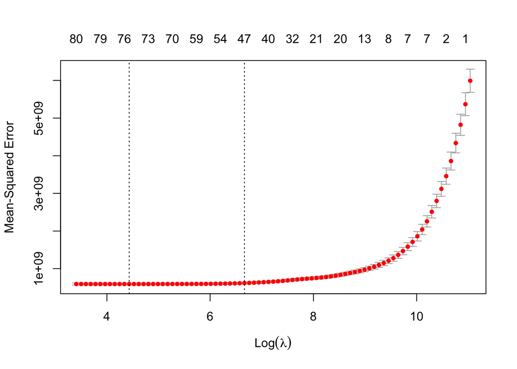

```r
plot(lasso.cv)
```